# Mixed models excercises part 1

Epidemiology and Big Data

## Introduction to Multilevel Modeling

During this computer lab we will 1) Try to reproduce the results from the lectures 2) Analyze data from a multi-center trial on hypertension 3) Analyze data from a cross-over trial (also, coincidentally, on hypertension) 4) Look at the secondary question (about single- vs mixed-gender schools) in the London School data 5) Look at some descriptive statistics for a longitudinal study

**Note:** You may wish to consult the document “Fitting linear mixed effects models in R.docx” on Blackboard for some explanation about the two most common packages used to fit mixed models in R.

### Exercise 1

Try to reproduce the analysis of the schools dataset (**school.Rdata**) so far.

Before we get started, we’ll first load a few packages we will need for our analysis.

```r
library(foreign)
library(nlme)
library(psych)
library(ggplot2)
```

If you get an error message that the package is not available, you will first have to install it. For instance the foreign library: `install.packages("foreign")`, or use the menu in RStudio (Tools - Install Packages).

Read the data in as a data frame store it in the object “**london**”, and examine the first few lines of data in the data frame. Use the `summary()` function to get quick descriptive statistics of all the variables.

```r
load(file = "school.Rdata")
head(london)
```

```
##   school student normexam standlrt gender schgend  avslrt schav vrband
## 1      1       1  0.26132  0.61906      1       1 0.16617     2      1
## 2      1       2  0.13407  0.20580      1       1 0.16617     2      2
## 3      1       3 -1.72390 -1.36460      0       1 0.16617     2      3
## 4      1       4  0.96759  0.20580      1       1 0.16617     2      2
## 5      1       5  0.54434  0.37110      1       1 0.16617     2      2
## 6      1       6  1.73490  2.18940      0       1 0.16617     2      1
```

```r
summary(london)
```

```
##      school         student         normexam            standlrt
##  Min.   : 1.00   Min.   :  1.0   Min.   :-3.666100   Min.   :-2.93500
##  1st Qu.:14.00   1st Qu.: 16.0   1st Qu.:-0.699510   1st Qu.:-0.62071
##  Median :29.00   Median : 33.0   Median : 0.004322   Median : 0.04050
##  Mean   :31.01   Mean   : 38.7   Mean   :-0.000118   Mean   : 0.00181
##  3rd Qu.:47.00   3rd Qu.: 54.0   3rd Qu.: 0.678760   3rd Qu.: 0.61906
##  Max.   :65.00   Max.   :198.0   Max.   : 3.666100   Max.   : 3.01600
##      gender          schgend          avslrt              schav
##  Min.   :0.0000   Min.   :1.000   Min.   :-0.755960   Min.   :1.000
##  1st Qu.:0.0000   1st Qu.:1.000   1st Qu.:-0.149340   1st Qu.:2.000
##  Median :1.0000   Median :1.000   Median :-0.020198   Median :2.000
##  Mean   :0.6001   Mean   :1.805   Mean   : 0.001811   Mean   :2.127
##  3rd Qu.:1.0000   3rd Qu.:3.000   3rd Qu.: 0.210520   3rd Qu.:3.000
##  Max.   :1.0000   Max.   :3.000   Max.   : 0.637660   Max.   :3.000
##      vrband
##  Min.   :1.000
##  1st Qu.:1.000
##  Median :2.000
##  Mean   :1.843
##  3rd Qu.:2.000
##  Max.   :3.000
```

1. Make a scatterplot of all 4059 data points, looking at the relation between normexam and standlrt.

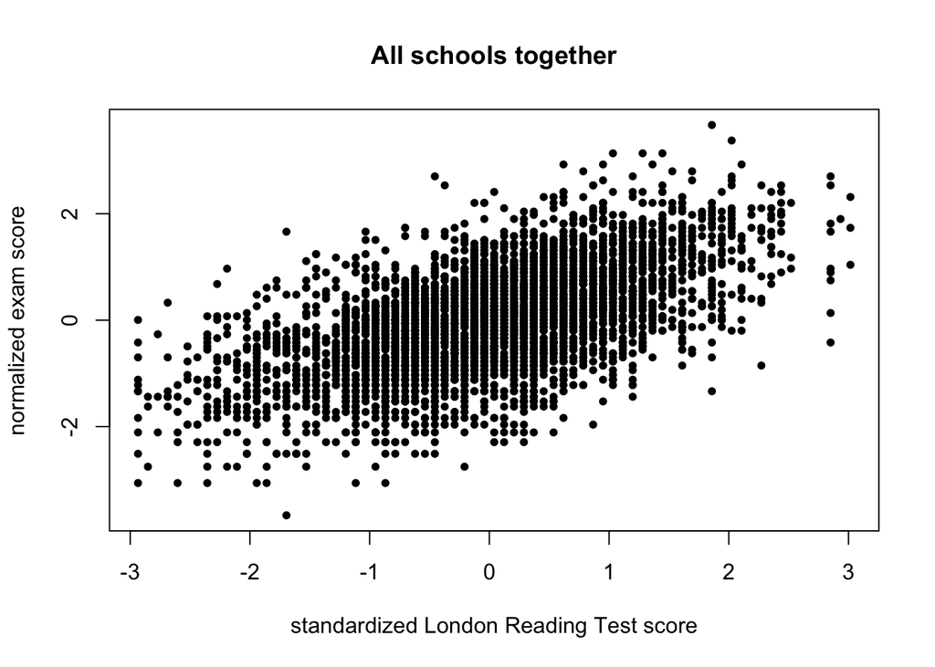

```r
plot(london$standlrt, london$normexam,
     xlab="standardized London Reading Test score",
     ylab="normalized exam score", main="All schools together", cex.main=1.15, pch=20)
```

2. Make a (simple) linear regression model of normexam on standlrt, and ask for a summary of that model.

```r
simple <- lm(london$normexam~london$standlrt)
summary(simple)
```

```
##
## Call:
## lm(formula = london$normexam ~ london$standlrt)
##
## Residuals:
##      Min       1Q   Median       3Q      Max
## -2.65617 -0.51847  0.01265  0.54397  2.97399
##
## Coefficients:
##                  Estimate Std. Error t value Pr(>|t|)
## (Intercept)     -0.001195   0.012642  -0.095    0.925
## london$standlrt  0.595055   0.012730  46.744   <2e-16 ***
## ---
## Signif. codes:  0 '***' 0.001 '**' 0.01 '*' 0.05 '.' 0.1 ' ' 1
##
## Residual standard error: 0.8054 on 4057 degrees of freedom
## Multiple R-squared:   0.35,  Adjusted R-squared:  0.3499
## F-statistic:  2185 on 1 and 4057 DF,  p-value: < 2.2e-16
```

3. Get individual scatterplots of the relation between normexam and standlrt for the 65 schools separately.

For visualizing longitudinal data, the `ggplot()` function in `ggplot2` package is very useful. The logic of the functions is not immediately obvious (i.e. I totally stole this code), but if you stick with it, it should become clearer. (For complete documentation of ggplot2, see http://ggplot2.tidyverse.org/reference/.)

We start by defining a base for the graphs and storing it in object called `p`. The `aes` stands for ‘aesthetic’, and defines the dataset, the X & Y variables, and any stratification (group) variables. Note that when you run the first line, nothing happens. Only when you ask for the object `p` (and add options to it) do you actually get a plot. Here, we do a number of steps in one: we add points to p, plus a regression line (‘smoothed’ but with lm = linear model) and a ‘facet wrap’, asking for stratification on school. If you want, you can add one option at a time, to see what each option does (so, for instance, start with `p + geom_point` to get the same scatterplot as above, and `p + geom_point + geom_smooth(method=lm, se = FALSE)` to get the scatterplot plus the regression line).

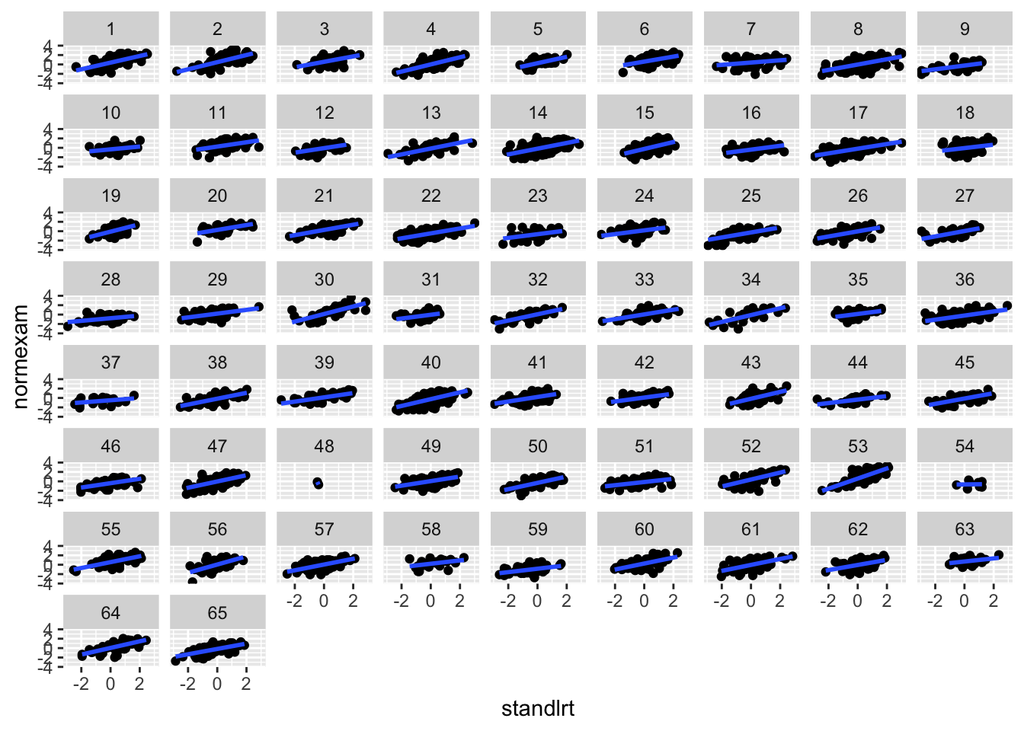

```r
p <- ggplot(data = london, aes(x = standlrt, y = normexam))
p + geom_point() + geom_smooth(method=lm, se = FALSE) + facet_wrap(~school)
```

4. Run a linear regression of normexam on standlrt per school, and get the mean and SD’s of the regression coefficients.

```r
persch <- lmList(normexam~standlrt| school, data=london)
mean(coef(persch)[,1])
```

```
## [1] -0.06812356
```

```r
mean(coef(persch)[,2])
```

```
## [1] 0.4245775
```

```r
sd(coef(persch)[,1])
```

```
## [1] 0.5191847
```

```r
sd(coef(persch)[,2])
```

```
## [1] 0.9394058
```

5. Fit a linear mixed model with random intercept to predict exam scores using the LRT scores.

```r
sch.lme.1 <- lme(fixed=normexam~standlrt, random=~1 | school, data=london, method="ML")
summary(sch.lme.1)
```

```
## Linear mixed-effects model fit by maximum likelihood
##  Data: london
##        AIC      BIC    logLik
##   9365.213 9390.447 -4678.606
##
## Random effects:
##  Formula: ~1 | school
##         (Intercept)  Residual
## StdDev:   0.3035269 0.7521481
##
## Fixed effects: normexam ~ standlrt
##                 Value  Std.Error   DF  t-value p-value
## (Intercept) 0.0023871 0.04003241 3993  0.05963  0.9525
## standlrt    0.5633697 0.01246844 3993 45.18366  0.0000
##  Correlation:
##          (Intr)
## standlrt 0.008
##
## Standardized Within-Group Residuals:
##        Min         Q1        Med         Q3        Max
## -3.7161719 -0.6304245  0.0286690  0.6844298  3.2680306
##
## Number of Observations: 4059
## Number of Groups: 65
```

6. Add a random slope to the model in (e). Interpret this model.

```r
sch.lme.2 <- lme(fixed=normexam~standlrt, random=~standlrt | school, data=london, method="ML")
summary(sch.lme.2)
```

```
## Linear mixed-effects model fit by maximum likelihood
##  Data: london
##       AIC      BIC   logLik
##   9328.84 9366.693 -4658.42
##
## Random effects:
##  Formula: ~standlrt | school
##  Structure: General positive-definite, Log-Cholesky parametrization
##             StdDev    Corr
## (Intercept) 0.3007308 (Intr)
## standlrt    0.1205745 0.497
## Residual    0.7440777
##
## Fixed effects: normexam ~ standlrt
##                  Value  Std.Error   DF   t-value p-value
## (Intercept) -0.0115074 0.03979168 3993 -0.289191  0.7725
## standlrt     0.5567280 0.01994280 3993 27.916244  0.0000
##  Correlation:
##          (Intr)
## standlrt 0.365
##
## Standardized Within-Group Residuals:
##         Min          Q1         Med          Q3         Max
## -3.83123175 -0.63247485  0.03404143  0.68320630  3.45617381
##
## Number of Observations: 4059
## Number of Groups: 65
```

In the output above, the standard deviations of the random effects and residuals are displayed. To extract the *variances* of the random effects, use `VarCorr()` function:

```r
VarCorr(sch.lme.2)
```

```
## school = pdLogChol(standlrt)
##             Variance   StdDev    Corr
## (Intercept) 0.09043900 0.3007308 (Intr)
## standlrt    0.01453822 0.1205745 0.497
## Residual    0.55365165 0.7440777
```

Of course we could have squared the standard deviations to get the variances of the random effects and the residuals, but the `VarCorr()` function in combination with an `lme` object will display both the variances and the standard deviations of the random effects, and of the residuals.

Take a look at first few random effects of this new model:

```r
head(ranef(sch.lme.2))
```

```
##   (Intercept)   standlrt
## 1  0.37492828 0.12497491
## 2  0.47020355 0.16472764
## 3  0.47977967 0.08084160
## 4  0.03501158 0.12720722
## 5  0.24627621 0.07205202
## 6  0.51840173 0.05859393
```

These are the estimated random effects for the intercept $\hat{b}_{0i}$ and LRT slope $\hat{b}_{1i}$ for the first few schools. These first 6 intercepts and slopes are coincidentally all positive, meaning that these 6 schools all have a higher than average intercept and higher than average LRT slope. To examine all 65 intercepts and slopes, you can run the command `ranef(sch.lme.2)`.

7. Add child- and school-level explanatory variables.

Let’s add gender (a child-level variable) to the mixed model with random intercept & random slope:

```r
sch.lme.3 <- lme(normexam~standlrt + factor(gender), random=~standlrt | school, data=london, method="ML")
summary(sch.lme.3)
```

```
## Linear mixed-effects model fit by maximum likelihood
##  Data: london
##        AIC      BIC    logLik
##   9301.358 9345.518 -4643.679
##
## Random effects:
##  Formula: ~standlrt | school
##  Structure: General positive-definite, Log-Cholesky parametrization
##             StdDev    Corr
## (Intercept) 0.2936242 (Intr)
## standlrt    0.1212575 0.533
## Residual    0.7416710
##
## Fixed effects: normexam ~ standlrt + factor(gender)
##                      Value  Std.Error   DF   t-value p-value
## (Intercept)     -0.1117670 0.04305229 3992 -2.596075  0.0095
## standlrt         0.5529634 0.01998634 3992 27.667060  0.0000
## factor(gender)1  0.1757988 0.03225659 3992  5.450011  0.0000
##  Correlation:
##                 (Intr) stndlr
## standlrt         0.370
## factor(gender)1 -0.426 -0.036
##
## Standardized Within-Group Residuals:
##         Min          Q1         Med          Q3         Max
## -3.83299563 -0.63770664  0.02428286  0.68232962  3.45010389
##
## Number of Observations: 4059
## Number of Groups: 65
```

Now we’ll add two school-level variables (school gender & school average):

```r
sch.lme.4 <- lme(normexam~standlrt + factor(gender)+ factor(schgend) + factor(schav),
      random=~standlrt | school, data=london, method="ML")
summary(sch.lme.4)
```

```
## Linear mixed-effects model fit by maximum likelihood
##  Data: london
##        AIC      BIC    logLik
##   9300.414 9369.809 -4639.207
##
## Random effects:
##  Formula: ~standlrt | school
##  Structure: General positive-definite, Log-Cholesky parametrization
##             StdDev    Corr
## (Intercept) 0.2660309 (Intr)
## standlrt    0.1212542 0.499
## Residual    0.7417279
##
## Fixed effects: normexam ~ standlrt + factor(gender) + factor(schgend) + factor(schav)
##                       Value  Std.Error   DF   t-value p-value
## (Intercept)      -0.2647657 0.08159434 3992 -3.244902  0.0012
## standlrt          0.5515520 0.02006950 3992 27.482097  0.0000
## factor(gender)1   0.1671313 0.03385088 3992  4.937282  0.0000
## factor(schgend)2  0.1869684 0.09777600   60  1.912211  0.0606
## factor(schgend)3  0.1570156 0.07780641   60  2.018029  0.0481
## factor(schav)2    0.0668879 0.08534936   60  0.783696  0.4363
## factor(schav)3    0.1742650 0.09876108   60  1.764511  0.0827
##  Correlation:
##                  (Intr) stndlr fct()1 fctr(schg)2 fctr(schg)3 fctr(schv)2
## standlrt          0.205
## factor(gender)1  -0.182 -0.037
## factor(schgend)2 -0.340  0.002  0.157
## factor(schgend)3 -0.253  0.025 -0.235  0.230
## factor(schav)2   -0.761 -0.035 -0.014  0.061       0.000
## factor(schav)3   -0.648 -0.080 -0.018  0.061      -0.083       0.622
##
## Standardized Within-Group Residuals:
##         Min          Q1         Med          Q3         Max
## -3.83388977 -0.63434044  0.02308039  0.67675187  3.41363835
##
## Number of Observations: 4059
## Number of Groups: 65
```

To get *approximate* (Wald) confidence intervals, produced by the `intervals()` function in nlme package:

```r
intervals(sch.lme.4)
```

```
## Approximate 95% confidence intervals
##
##  Fixed effects:
##                         lower        est.      upper
## (Intercept)      -0.424598124 -0.26476566 -0.1049332
## standlrt          0.512238511  0.55155200  0.5908655
## factor(gender)1   0.100821935  0.16713130  0.2334407
## factor(schgend)2 -0.008444022  0.18696837  0.3823808
## factor(schgend)3  0.001513856  0.15701559  0.3125173
## factor(schav)2   -0.103688945  0.06688792  0.2374648
## factor(schav)3   -0.023116161  0.17426500  0.3716462
## attr(,"label")
## [1] "Fixed effects:"
##
##  Random Effects:
##   Level: school
##                                lower      est.     upper
## sd((Intercept))           0.21573177 0.2660309 0.3280576
## sd(standlrt)              0.08918693 0.1212542 0.1648514
## cor((Intercept),standlrt) 0.11905278 0.4992424 0.7517526
##
##  Within-group standard error:
##     lower      est.     upper
## 0.7255056 0.7417279 0.7583129
```

8. For the model in (a), we will write a brief description of the statistical model used. Fill in the blanks: “A linear mixed effects model was estimated, using fixed effects for ______________. A random __________ and a random effect of _________ per __________ were added to correct for ______________.”

A linear mixed effects model was estimated, using fixed effects for the standardized London Reading Test, student gender, school gender, and school performance. A random intercept and a random effect of the standardized London Reading Test per school were added to correct for correlation of children within schools.

### Exercise 2

**Pay special attention to Part c of this question. It may be used in the exam.**

A multi-center, randomized, double-blind clinical trial was done to compare two treatments for hypertension. One treatment was a new drug (1 = Carvedilol) and the other was a standard drug for controlling hypertension (2 = Nifedipine). Twenty-nine centers participated in the trial and patients were randomized in order of entry. One pre-randomization and four post-treatment visits were made. Here, we will concentrate on the last recorded measurement of diastolic blood pressure (primary endpoint: dbp). The data can be found in the data file **dbplast.Rdata**. Read the data into R. The research question is which of the two medicines (treat) is more effective in reducing DBP. Since baseline (pre-randomization) DBP (dbp) will likely be associated with post-treatment DBP and will reduce the variation in the outcome (thereby increasing our power to detect a treatment effect), we wish to include it here as a covariate.

1. Make some plots to describe the patterns of the data.

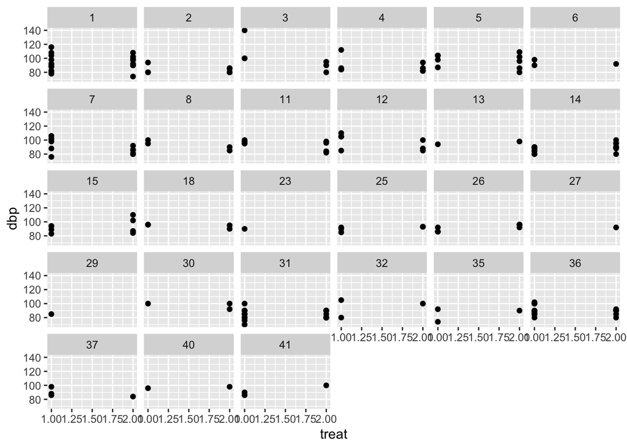

```r
load(file = "dbplast.Rdata")
trial <- dbplast
p1 <- ggplot(data = trial, aes(x = treat, y = dbp, group=center))
p1 + geom_point() + facet_wrap(~center)
```

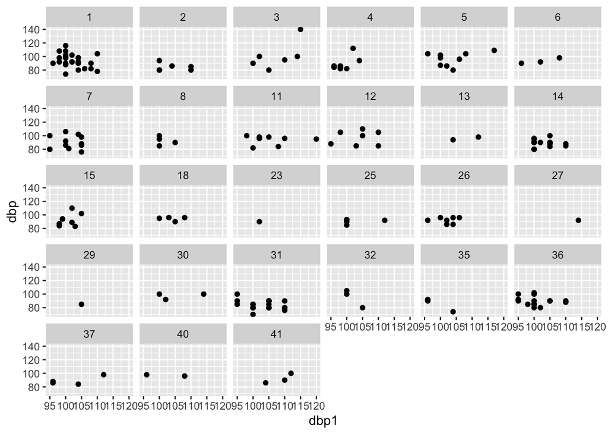

```r
p2 <- ggplot(data = trial, aes(x = dbp1, y = dbp, group=center))
p2 + geom_point() + facet_wrap(~center)
```

There are no immediately discernible differences between the two treatments in the final DBP level of the patients. There also does not appear to be a strong relation between pre-randomization DBP and final DBP.

2. Fit a model to answer the research question, using maximum likelihood estimation, taking into account that patients within centers may have correlated data. Interpret the coefficients of the model.

We want to examine the difference between treatment groups while controlling for baseline DBP. The required analysis (if in a single center) would be an ANCOVA: a linear regression with one categorical and one continuous variable. Since this is a multi-center trial, we need to also add (at least) a random intercept per center. Depending on further theory or on the results of the graphs in (a), we might also want to add a random effect (slope) per center for baseline DPB and/or a random effect for treatment. The former allows each center to have its own DBP-DBP1 slope (in this data there does not appear to be much variation in slopes, see the second plot in (a)); the latter would allow the treatment effect to differ per center (not something one generally hopes for, and also not very likely given the first plot in (a)).

Since there is no (theoretical or practical) reason to add random effects of baseline DBP or treatment, we use a model with only a random intercept per center. This model assumes centers have different mixes of patients with (on average) higher or lower blood pressure, but that the trend between DBP and baseline and the difference between treatments is the same in every center. Note that the code below assumes the variable treat has been coded as a factor/categorical variable; if it is numeric in your dataset, please use factor(treat) in your model.

```r
lme.1 <- lme(fixed=dbp ~ dbp1 + factor(treat), random=~1|center,
  data=trial, method="ML")
summary(lme.1)
```

```
## Linear mixed-effects model fit by maximum likelihood
##  Data: trial
##        AIC      BIC    logLik
##   1393.739 1410.052 -691.8694
##
## Random effects:
##  Formula: ~1 | center
##         (Intercept) Residual
## StdDev:    2.824933 8.406353
##
## Fixed effects: dbp ~ dbp1 + factor(treat)
##                   Value Std.Error  DF   t-value p-value
## (Intercept)    74.10138 13.630882 164  5.436287  0.0000
## dbp1            0.17470  0.131612 164  1.327382  0.1862
## factor(treat)2 -1.11787  1.230104 164 -0.908764  0.3648
##  Correlation:
##                (Intr) dbp1
## dbp1           -0.997
## factor(treat)2 -0.122  0.080
##
## Standardized Within-Group Residuals:
##         Min          Q1         Med          Q3         Max
## -2.16658330 -0.72441696 -0.07447943  0.55358319  5.04172608
##
## Number of Observations: 193
## Number of Groups: 27
```

Patients on treatment 2 (Nifedipine) have, on average, a 1.1 mmHg lower DBP than patients on treatment 1 (Carvedilol), 95% CI (-3.5; 1.3). For every 1 mmHg increase in baseline DBP, a patient has, on average, a 0.17 (95% CI: -0.08 - 0.43) mmHg increase in DBP at the end of the study. Neither of these variables appears to be statistically significant (unsurprising, given the descriptive statistics), nor particularly clinically relevant.

The intercept, 74.10, is the average DBP at the end of the study for a patient on tx 1 with a baseline DBP of 0(!).

The variance of the random intercept is 7.98 (=2.822), and the residual variance is 70.67 (=8.412), indicating that there is quite a bit more variance in diastolic blood pressure among patients within centers than among the different centers.

3. Make a new baseline dbp variable, centered around its mean. Re-fit the model in (b) using the centered baseline blood pressure variable, using maximum likelihood estimation.

```r
trial$cdbp1 <- trial$dbp1 - mean(trial$dbp1)
lme.2 <- lme(fixed=dbp ~ cdbp1 + factor(treat), random=~1|center,
  data=trial, method="ML")
summary(lme.2)
```

```
## Linear mixed-effects model fit by maximum likelihood
##  Data: trial
##        AIC      BIC    logLik
##   1393.739 1410.052 -691.8694
##
## Random effects:
##  Formula: ~1 | center
##         (Intercept) Residual
## StdDev:    2.824932 8.406354
##
## Fixed effects: dbp ~ cdbp1 + factor(treat)
##                   Value Std.Error  DF  t-value p-value
## (Intercept)    92.04376 1.0649560 164 86.42963  0.0000
## cdbp1           0.17470 0.1316116 164  1.32738  0.1862
## factor(treat)2 -1.11787 1.2301043 164 -0.90876  0.3648
##  Correlation:
##                (Intr) cdbp1
## cdbp1          -0.068
## factor(treat)2 -0.548  0.080
##
## Standardized Within-Group Residuals:
##         Min          Q1         Med          Q3         Max
## -2.16658325 -0.72441695 -0.07447933  0.55358329  5.04172612
##
## Number of Observations: 193
## Number of Groups: 27
```

### Exercise 3

In a small crossover study two drugs, A and B, are compared for their effect on the diastolic blood pressure (DBP). Each patient in the study receives the two treatments in a random order and separated in time (“wash-out” period) so that one treatment does not influence the blood pressure measurement obtained after administering the other treatment (i.e. to rule out carry-over effect) . The data are given in the data file **crossover.Rdata**.

Note that subject 4 has only the measurement for drug A and that subject 16 has only the measurement for drug B.

1. Use descriptive statistics to get a feel for the data. Which drug seems to be better at reducing DBP?

```r
load(file = "crossover.Rdata")
cross <- crossover
tapply(cross$Y,cross$DRUG,mean)
```

```
##        A        B
## 104.5000 113.6111
```

```r
tapply(cross$Y,cross$DRUG,sd)
```

```
##        A        B
## 12.94899 11.01944
```

```r
tapply(cross$Y,cross$PERIOD,mean)
```

```
##        1        2
## 109.5294 108.6316
```

```r
tapply(cross$Y,cross$PERIOD,sd)
```

```
##        1        2
## 12.73341 13.03930
```

Mean DBP for drug A is 104.5 (SD 12.9); for drug B 113.6 (11.0).Mean DBP for period 1 is 109.5 (SD 12.7); for period 2 108.6 (13.0).

2. Fit a model to the data, looking at drug and period effect and correcting for the fact that (most) patients have more than one DBP measurement. Which variable(s) do you choose as random?

Because we have two measurements per patient, we need (at least?) a random intercept. Do we need more random effects? A random effect for drug would assume that the treatment effect is different for each patient. While this could well be the case, in order to estimate such an effect, we would need more than one measurement per patient per drug! The same holds true for a random effect for period (additionally, a different treatment effect per period violates one of the important assumptions of a cross-over trial). In this case, a model with a random effect per patient is both the least and the most we can do.

Fit a mixed model with random intercept per patient:

```r
cross.lme1 <- lme(Y~factor(DRUG) + factor(PERIOD),
  random= ~1|PATIENT, method="ML", data=cross)
summary(cross.lme1)
```

```
## Linear mixed-effects model fit by maximum likelihood
##  Data: cross
##        AIC      BIC    logLik
##   280.6751 288.5927 -135.3375
##
## Random effects:
##  Formula: ~1 | PATIENT
##         (Intercept) Residual
## StdDev:    8.980622 7.276865
##
## Fixed effects: Y ~ factor(DRUG) + factor(PERIOD)
##                     Value Std.Error DF  t-value p-value
## (Intercept)     104.95515  3.115860 18 33.68416  0.0000
## factor(DRUG)B     9.36033  2.581338 15  3.62615  0.0025
## factor(PERIOD)2  -1.25006  2.583876 15 -0.48379  0.6355
##  Correlation:
##                 (Intr) f(DRUG
## factor(DRUG)B   -0.388
## factor(PERIOD)2 -0.427 -0.058
##
## Standardized Within-Group Residuals:
##         Min          Q1         Med          Q3         Max
## -2.28987540 -0.42035217 -0.02943319  0.44467310  1.49482872
##
## Number of Observations: 36
## Number of Groups: 19
```

```r
intervals(cross.lme1)
```

```
## Approximate 95% confidence intervals
##
##  Fixed effects:
##                     lower       est.      upper
## (Intercept)     98.687664 104.955154 111.222644
## factor(DRUG)B    4.092571   9.360326  14.628082
## factor(PERIOD)2 -6.522999  -1.250063   4.022873
## attr(,"label")
## [1] "Fixed effects:"
##
##  Random Effects:
##   Level: PATIENT
##                    lower     est.    upper
## sd((Intercept)) 5.806065 8.980622 13.89092
##
##  Within-group standard error:
##     lower      est.     upper
##  5.231807  7.276865 10.121316
```

3. Interpret the results of the model. Is there a difference between the two treatments? Is there a period effect?

On drug B, the average DBP is 9.3 (95% CI 4.1-14.6) mmHg higher than on A (the reference category), Wald p=0.0025. So drug A works better in decreasing DBP. The average DBP in period 2 is slightly (and not statistically significantly) lower than in period 1: -1.25 (95% CI -6.5 – 4.0), so no significant period effect (Wald p=0.6355).

4. What other hypothesis might we want to test here?

It might be interesting to examine a (fixed) period*drug interaction. A significant interaction would indicate that (despite the wash-out period) the order in which the drugs were taken has an influence on one’s blood pressure. This could be medically plausible; however, with the current design (each patient is given only A then B or B then A and the DBP measured only once on each drug) this hypothesis cannot be tested!

### Exercise 4

A secondary question regarding the school exam data (exercises 1 & 2) was proposed in the lecture. Use R to address the question: is the difference between boys and girls the same for single-sex and mixed-gender schools? (*Note: you’ll need to make a new variable for single-gender (schgend = 2 or 3) vs mixed-gender (schgend = 1) schools before proceeding with the analysis.*)

```r
# make new variable mixed gender (schgend = 1 vs 2 or 3)
london$mixed <- as.numeric(london$schgend==1)
table(london$mixed,london$schgend) # check new variable
```

```
##
##        1    2    3
##   0    0  513 1377
##   1 2169    0    0
```

```r
# mixed model with random intercept & random slope, plus gender, school gender & school avg
sch.lme.sub <- lme(normexam~standlrt + factor(gender)+ factor(mixed) + factor(schav) +
   factor(gender)*factor(mixed), random=~standlrt | school, data=london, method="ML")
summary(sch.lme.sub)
```

```
## Linear mixed-effects model fit by maximum likelihood
##  Data: london
##        AIC      BIC    logLik
##   9300.414 9369.809 -4639.207
##
## Random effects:
##  Formula: ~standlrt | school
##  Structure: General positive-definite, Log-Cholesky parametrization
##             StdDev    Corr
## (Intercept) 0.2660302 (Intr)
## standlrt    0.1212546 0.499
## Residual    0.7417279
##
## Fixed effects: normexam ~ standlrt + factor(gender) + factor(mixed) + factor(schav) +      factor(gender) * factor(mixed)
##                                     Value  Std.Error   DF   t-value p-value
## (Intercept)                    -0.0777973 0.10389282 3991 -0.748823  0.4540
## standlrt                        0.5515520 0.02006954 3991 27.482049  0.0000
## factor(gender)1                 0.1371785 0.10481254 3991  1.308799  0.1907
## factor(mixed)1                 -0.1869683 0.09777574   61 -1.912216  0.0605
## factor(schav)2                  0.0668879 0.08534913   61  0.783698  0.4362
## factor(schav)3                  0.1742650 0.09876083   61  1.764516  0.0827
## factor(gender)1:factor(mixed)1  0.0299527 0.11006608 3991  0.272134  0.7855
##  Correlation:
##                                (Intr) stndlr fctr(g)1 fctr(m)1 fct()2 fct()3
## standlrt                        0.162
## factor(gender)1                -0.614  0.006
## factor(mixed)1                 -0.674 -0.002  0.711
## factor(schav)2                 -0.540 -0.035 -0.061   -0.061
## factor(schav)3                 -0.451 -0.080 -0.124   -0.061    0.622
## factor(gender)1:factor(mixed)1  0.586 -0.017 -0.952   -0.726    0.054  0.113
##
## Standardized Within-Group Residuals:
##         Min          Q1         Med          Q3         Max
## -3.83388964 -0.63434049  0.02308039  0.67675190  3.41363881
##
## Number of Observations: 4059
## Number of Groups: 65
```

The effect of school gender on the exam scores of boys and girls is not statistically significant (p = 0.7855), but for the interpretation: boys (ref) at single-gender schools (ref): reference category boys (ref) at mixed-gender schools: 0.19 SD lower than ref (boys, single-sex) girls at single-gender schools (ref): 0.14 SD higher than ref (boys, single-sex) girls at mixed-gender schools: 0.14 - 0.19 + 0.03 = -0.02 so 0.02 SD lower than boys at single-gender schools.

### Exercise 5 (Preparation for lecture 2)

In lecture 2 we will spend time examining different ways of analyzing the Reisby dataset. This is a longitudinal dataset on 66 patients with endogenous or exogenous depression. Patients are measured every week starting at baseline; from week 1 on, they were all treated with imipramine. The outcome is the score on the Hamilton Depression Rating Scale (HDRS), a score based on a questionnaire administered by a health care professional. The score ranges - theoretically - from 0 (no depressive symptoms) to 52, where scores higher than 20 indicate moderate to very severe depression. The questions of interest are how the HDRS score changes over time for the patients, and whether the patterns of HDRS over time differ for patients with endogenous and exogenous depression. The data is available in both a “wide” and a “long” format: **reisbywide.Rdata** and **reisbylong.Rdata**.

1. We heard this morning that longitudinal data is also multi-level data. How many levels do we have here? What does each level represent?

2 levels: measurements (level 1) within patients (level 2).

**Others answers in next lecture.**

2. Use descriptive statistics (means, SDs, graphs) to get a feel for the data, concentrating on the patterns (individual and/or group) of HDRS over time (note that there are two versions of the dataset given, one “wide” and one “long”. For some graphs and descriptive statistics, one version may be easier to use than the other.
3. What do you notice about the mean HDRS score over time? And the variation?
4. Time was measured at 6 discrete moments. How would you want to incorporate time in the fixed part of the model: as discrete or continuous? Explain your answer.
5. If you were to include a random intercept in the model, for which level would you include an intercept?
6. Do you think it is necessary to include time in the random part of the model? Why or why not?